# R Raster Data Analysis

```r
data.path <- "C:\\Users\\jakal\\OneDrive - University of Idaho\\Documents\\GitHub\REM504-DataScience\\Practice_Datasets"
```

[output not shown]

Loading raster data in R is *EASY*. You just issue the raster() function and give it the name of a raster file.

```r
# First, let's get some info about the raster layer
GDALinfo(file.path(data.path,ps.file))
```

[output not shown]

```
rows        383
columns     421
bands       4
lower left origin.x        325865.6
lower left origin.y        3606819
res.x       3.125
res.y       3.125
ysign       -1
oblique.x   0
oblique.y   0
driver      GTiff
projection  +proj=utm +zone=13 +datum=WGS84 +units=m +no_defs
file        C:/Users/jakal/OneDrive - University of Idaho/Documents/GitHub/REM504-DataScience/Practice_Datasets/PlanetScope_SR_2017-08-14.tif
apparent band summary:
```

| GDType | hasNoDataValue | NoDataValue | blockSize1 | blockSize2 |
| --- | --- | --- | --- | --- |
| UInt16 | FALSE | 0 | 2 | 421 |
| UInt16 | FALSE | 0 | 2 | 421 |
| UInt16 | FALSE | 0 | 2 | 421 |
| UInt16 | FALSE | 0 | 2 | 421 |

```
apparent band statistics:
```

| Bmin | Bmax | Bmean | Bsd |
| --- | --- | --- | --- |
| 0 | 65535 | NA | NA |
| 0 | 65535 | NA | NA |
| 0 | 65535 | NA | NA |
| 0 | 65535 | NA | NA |

```
Metadata:
AREA_OR_POINT=Area
```

Now let’s explore this dataset a bit

```r
# Check extent and resolution
extent(ps.image)
res(ps.image)

# Check the coordinate system
crs(ps.image)
```

[output not shown]

Let’s look at these raster layers!

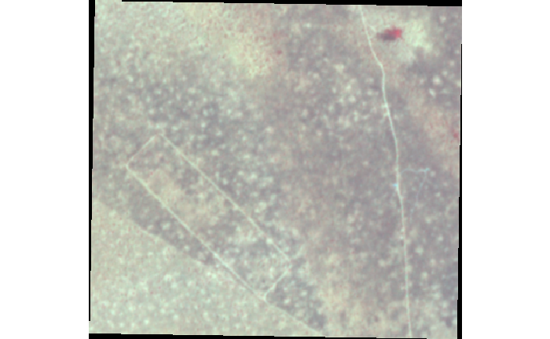

## Raster operations

Working on raster data in R is also pretty easy. The big tricks are to make sure you have your data in the same coordinate system and that they all have consistent resolution.

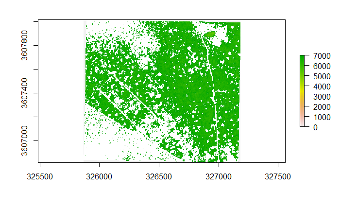

## Raster math

raster math is a general term for when you want to perform arithmetic operations on a cell-by-cell basis. Raster math is what you’d use to calculate an index like NDVI from a satellite image.

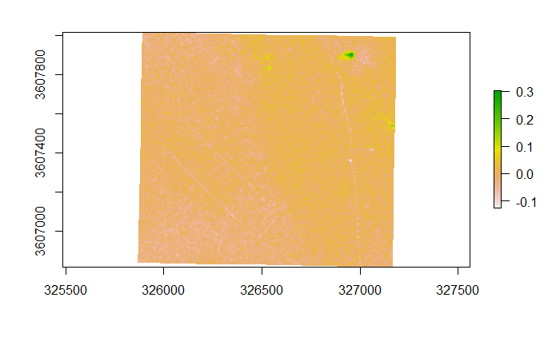

## Zonal statistics

Zonal statistics are calculated for distinct regions (zones) as defined by a polygon layer. In raster analysis this is super useful for calculating means, max, median, etc. for polygons. Let’s calculate the average NDVI value for a buffer around each of the points. The zonal() function in R will do this, but your “zones” need to be defined as a raster first. Luckily, we can get the same answer with the extract() function in most cases.

```r
ndvi.buffer
```

```
[1]  0.0097707937  0.0201998853 -0.0003219128  0.0099261184  0.0159673215 -0.0207116843
```